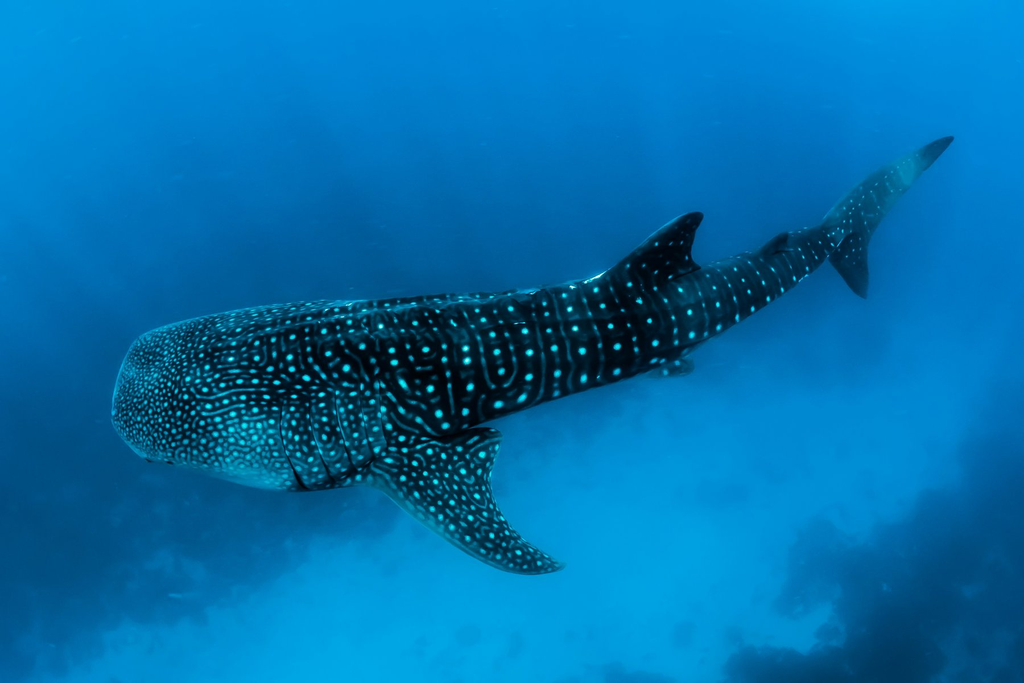

Key Findings & Graph Breakdown

# Discover the Profiles of Each Individual Whale Shark Tracked

This project analyzes 2,391 whale shark (*Rhincodon typus*) observations in Australia's Coral Sea collected by the Biopixel Oceans Foundation and James Cook University. The dataset combines 2,255 satellite transmissions from 18 individually named sharks along the Great Barrier Reef and Coral Sea reefs with 136 opportunistic sightings recorded from 2007 to 2018. Explore the profiles below to see each shark's trajectory, deep-water plateaus, and seasonal surges.

Pick any whale shark below, flip through with **Previous / Next**, or try **🎲 Random Shark** to meet each individual:

Whale Shark 1 of 18

### Megashark (Tag ID: 252324)

Male · Immature 423 Transmissions Span: 13.0 Months (2023-11-30 to 2024-12-31) Min. Distance: ~6,073 km Latitudes: 16.5°S to 9.7°S

### Alexios (Tag ID: 178953)

Male · Immature 357 Transmissions Span: 5.2 Months (2021-12-05 to 2022-05-12) Min. Distance: ~4,307 km Latitudes: 18.1°S to 11.1°S

- **Curve Pattern on Plot:** Rises rapidly and smoothly to 357 detections in just over 5 months (~2.3 transmissions/day) with no silent gap longer than 13 days.
- **Ecological Takeaway:** Indicates sustained surface and upper-water-column activity as this immature male traveled over 4,300 km along the outer Great Barrier Reef and Coral Sea basin from summer into autumn.

### Ali (Tag ID: 178954)

Female · Immature 273 Transmissions Span: 25.3 Months (2021-12-06 to 2024-01-15) Min. Distance: ~11,378 km Latitudes: 18.6°S to 7.9°S

- **Curve Pattern on Plot:** Stretches farthest right among all tagged sharks (25.3 months / >2 years), advancing in staircase-like seasonal bursts separated by gaps of up to 73 days.
- **Ecological Takeaway:** One of only two confirmed females in the tagged cohort and the dataset's long-distance marathoner, logging over 11,300 km between central Queensland latitudes and waters near Papua New Guinea.

### Sharpie (Tag ID: 252325)

Male · Immature 261 Transmissions Span: 3.2 Months (2023-12-01 to 2024-03-07) Min. Distance: ~1,544 km Latitudes: 13.5°S to 11.3°S

- **Curve Pattern on Plot:** One of the steepest initial slopes on the chart, packing 261 locations into 97 days (~2.7 uplinks/day) with a maximum gap of only 10 days.
- **Ecological Takeaway:** Stayed within a relatively tight northern reef band (11.3°S–13.5°S), spending long periods basking and filter-feeding at the surface during peak summer plankton productivity.

### Juanita (Tag ID: 172900)

Unknown Sex · Immature 204 Transmissions Span: 4.3 Months (2023-11-03 to 2024-03-14) Min. Distance: ~2,642 km Latitudes: 16.6°S to 8.1°S

- **Curve Pattern on Plot:** Climbs steadily from Month 0 to 204 detections across 4.3 months, punctuated by brief 1–3 week pauses (max gap 21 days).
- **Ecological Takeaway:** Tracked earlier in spring (early November) than most sharks and ranged widely across 8.5 degrees of latitude northward into the northern Coral Sea.

### GBR1 (Tag ID: 172899)

Unknown Sex · Immature 177 Transmissions Span: 4.8 Months (2018-10-26 to 2019-03-21) Min. Distance: ~3,677 km Latitudes: 14.2°S to 6.3°S

- **Curve Pattern on Plot:** Exceptionally smooth, unbroken upward line over nearly 5 months — never going more than 4 days without a satellite uplink.
- **Ecological Takeaway:** Reached the northernmost latitude of any shark in the dataset (6.3°S in Papua New Guinea waters), proving cross-border movement across the northern Coral Sea.

### Beizam (Tag ID: 243952)

Male · Subadult 98 Transmissions Span: 2.2 Months (2023-12-02 to 2024-02-08) Min. Distance: ~1,846 km Latitudes: 17.2°S to 11.3°S

- **Curve Pattern on Plot:** Steady 2.2-month climb to 98 detections across December–February with minimal transmission gaps.
- **Ecological Takeaway:** Notable as the **only Subadult** shark in an otherwise immature-dominated tagged group, cruising rapidly southward and offshore (~27 km/day) across nearly 6 degrees of latitude.

### Blancpain (Tag ID: 178957)

Female · Immature 73 Transmissions Span: 17.3 Months (2021-12-06 to 2023-05-16) Min. Distance: ~1,943 km Latitudes: 14.5°S to 8.1°S

- **Curve Pattern on Plot:** Features the most dramatic horizontal plateau on the entire plot — going silent for **276 consecutive days (~9 months)** before resuming transmissions past Month 15.
- **Ecological Takeaway:** Along with *Ali*, one of only two tagged females; demonstrates how whale sharks can spend months foraging in deep or remote waters without long surface intervals before reappearing the next season.

### GBR2 (Tag ID: 176413)

Male · Immature 69 Transmissions Span: 2.9 Months (2019-11-17 to 2020-02-13) Min. Distance: ~2,675 km Latitudes: 15.1°S to 10.8°S

- **Curve Pattern on Plot:** Moderate 3-month summer curve reaching 69 uplinks with occasional 1–2 week diving gaps.
- **Ecological Takeaway:** Covered high daily mileage (~30 km/day average between pings), moving briskly across outer Coral Sea reefs during the 2019–2020 summer season.

### Infamis (Tag ID: 243954)

Male · Immature 66 Transmissions Span: 2.4 Months (2023-12-01 to 2024-02-12) Min. Distance: ~644 km Latitudes: 13.8°S to 12.2°S

- **Curve Pattern on Plot:** Compact 2.4-month summer trajectory rising to 66 detections near the base of the main summer cluster.
- **Ecological Takeaway:** Showed strong site fidelity within a narrow 1.6° latitude band along the northern Great Barrier Reef shelf edge rather than making an immediate long-distance crossing.

### Jaap (Tag ID: 178948)

Male · Immature 63 Transmissions Span: 1.3 Months (2019-11-19 to 2019-12-28) Min. Distance: ~255 km Latitudes: 12.2°S to 11.6°S

- **Curve Pattern on Plot:** Steep short-duration curve reaching 63 locations within 39 days (~1.6 uplinks/day).
- **Ecological Takeaway:** Remained tightly localized around the Wreck Bay / northern reef aggregation hotspot during late November and December coral spawning.

### Halliday (Tag ID: 243955)

Male · Immature 53 Transmissions Span: 1.3 Months (2023-12-04 to 2024-01-12) Min. Distance: ~772 km Latitudes: 15.0°S to 11.3°S

- **Curve Pattern on Plot:** Climbs cleanly to 53 detections over 39 days across December and early January.
- **Ecological Takeaway:** Unlike *Jaap* over the same 39-day span, *Halliday* traveled more than three times farther (~772 km), heading southward along the outer reef margin.

### Hugh (Tag ID: 243951)

Male · Immature 53 Transmissions Span: 0.2 Months / 7 Days (2023-11-30 to 2023-12-07) Min. Distance: ~143 km Latitudes: 12.2°S to 12.0°S

- **Curve Pattern on Plot:** Appears nearly vertical near Month 0, recording 53 high-frequency transmissions in just one week (~7.6 uplinks/day!).
- **Ecological Takeaway:** Captures intense, continuous surface feeding right after tagging before the tag ceased reporting or detached.

### Fifty_Fathoms (Tag ID: 178951)

Male · Immature 24 Transmissions Span: 1.2 Months (2021-12-05 to 2022-01-11) Min. Distance: ~868 km Latitudes: 14.6°S to 11.5°S

- **Curve Pattern on Plot:** Low, gentle 1.2-month curve reaching 24 transmissions over 37 days.
- **Ecological Takeaway:** Despite fewer surface uplinks, covered nearly 870 km across 3 degrees of latitude — suggesting deeper travel with briefer surface intervals.

### Sapphire (Tag ID: 176409)

Male · Immature 24 Transmissions Span: 0.3 Months / 9 Days (2024-03-05 to 2024-03-14) Min. Distance: ~1,387 km Latitudes: 16.5°S to 12.7°S

- **Curve Pattern on Plot:** Short 9-day burst of 24 detections near the origin of the X-axis.
- **Ecological Takeaway:** Tracked in March (late summer/early autumn) rather than December, moving rapidly across wide Coral Sea distances in just over a week.

### Andrew (Tag ID: 243953)

Male · Immature 18 Transmissions Span: 0.2 Months / 5 Days (2023-12-01 to 2023-12-06) Min. Distance: ~76 km Latitudes: 12.2°S to 11.9°S

- **Curve Pattern on Plot:** Brief 5-day cluster of 18 transmissions right at Month 0.
- **Ecological Takeaway:** Represents short-term local foraging around the northern reef tagging site in early December before early tag loss or deep offshore departure.

### Dotti (Tag ID: 178949)

Male · Immature 10 Transmissions Span: 0.1 Months / 3 Days (2019-11-20 to 2019-11-23) Min. Distance: ~20 km Latitudes: 12.2°S

- **Curve Pattern on Plot:** Compact 10-point cluster at the bottom-left origin of the plot.
- **Ecological Takeaway:** Captures a 3-day snapshot of localized reef aggregation behavior at 12.2°S during the November 2019 tagging expedition.

### Ambitious (Tag ID: 176407)

Unknown Sex · Immature 9 Transmissions Span: 0.2 Months / 6 Days (2019-11-19 to 2019-11-25) Min. Distance: ~19 km Latitudes: 12.2°S to 12.1°S

## Mid-Year Offshore Dispersal (May–September)

Detection counts drop during the austral winter not because whale sharks vanish from the Pacific, but because individuals disperse widely across deep open-ocean basins and spend longer intervals foraging at depth where fin-mounted satellite tags cannot transmit through seawater.

## Summary Table of Key Whale Shark Trajectories

| Whale Shark / Record | Observation Type | First Recorded | Last Recorded | Span (Months) | Total Records | Pattern on Graph |
| --- | --- | --- | --- | --- | --- | --- |
| **Whale Shark (Megashark)** | Satellite Tag | 2023-11-30 | 2024-12-31 | 13.0 months | **423** | Highest individual curve; mid-year plateau followed by late-year surge |
| **Whale Shark (Alexios)** | Satellite Tag | 2021-12-05 | 2022-05-12 | 5.2 months | **357** | Rapid, steady surface-tracking climb across 5 months |
| **Whale Shark (Ali)** | Satellite Tag | 2021-12-06 | 2024-01-15 | 25.3 months | **273** | Longest tagged shark span (>2 years) with multi-season steps |
| **Whale Shark (Sharpie)** | Satellite Tag | 2023-12-01 | 2024-03-07 | 3.2 months | **261** | Very steep 3-month summer surface burst |
| **Whale Shark (Juanita)** | Satellite Tag | 2023-11-03 | 2024-03-14 | 4.3 months | **204** | Consistent summer reef foraging trajectory |
| **Whale Shark (Coral Sea Sighting)** | Opportunistic Sightings | 2007-11-05 | 2018-10-24 | 131.6 months | **136** | Long baseline spanning nearly 11 years across the X-axis |